# WeRateDogs Data analyzing and Visualizing

Introduction:

WeRateDaogs has over 6 million followers and has received international media coverage. One of those coverage were about the quote “they’re good dogs Brent”, this was an exchange in which WeRateDogs shut down a person having an issue with its system in humorous ways.

From studing of WeRateDogs in detail we success to discover some insights and answer the following questions.

What is the most popular dog type? What is the most popular dog stage? Is the highest ratings breed get the most of the retweets? What is the highest Dog stage according to rating score? Retweet count over time with favorite counts? What is relation between Retweet count over time and favorite counts?

# Visualization Data:

### Most popular rated Dogs

Twitter WeRateDogs account has over 6000+ tweets I was able to analyzed around 1500+ tweets. The most rated dog was golden retriever with more than 150 ratings.

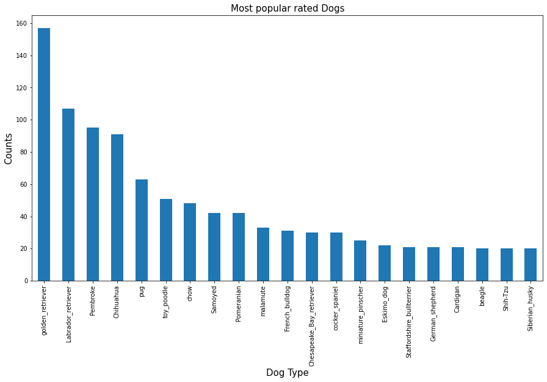

### The most popular Dog type is 'Golden retriever'

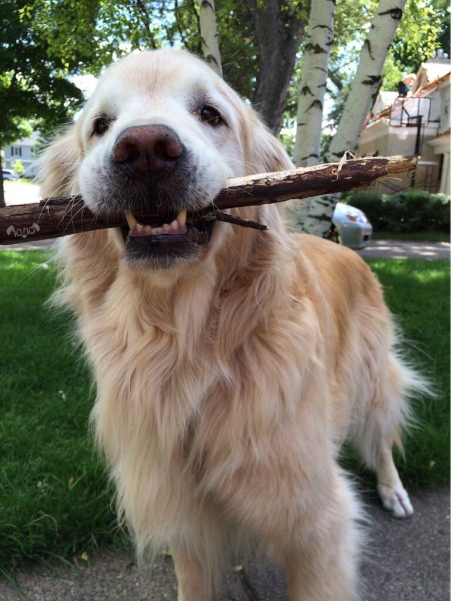

```python
# some pics for Golden retriver.#highest Dogs Stage according to total rate visitors
```

[figure not shown]

```python
# pic for Golden retriver.
```

### Most popular Dog stage

WeRateDogs account has main four dog stages (Doggo , Floofer, Pupper and Puppo) but the most popular one is:

(Pupper) with more thatn 160 counts.

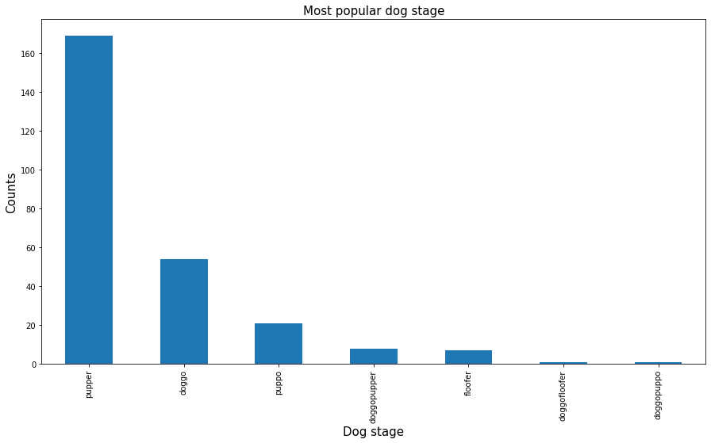

### The Most popular dog stage according to Counts is Pupper

### Retweet counts

many tweets have been retweeted more than 1000 times some more than even 50000 times. There is not a clear relationship between the ratings and the retweets but The highst ratings didn't get the most of the retweets.

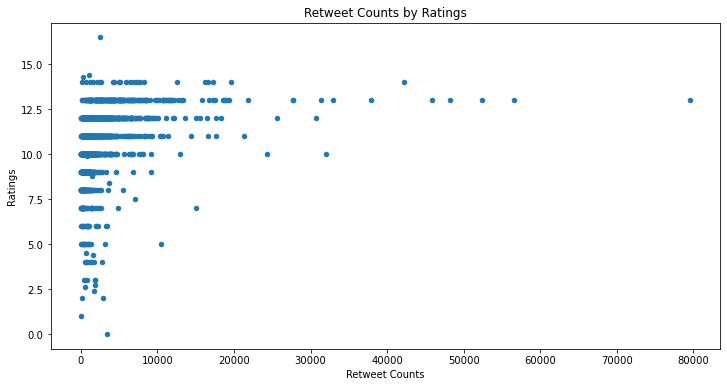

### The highst ratings didn't get the most of the retweets

### Dog stage according to total rating

Its clearly from the graph that Pupper stage has the top score rating with more than 1800 point.

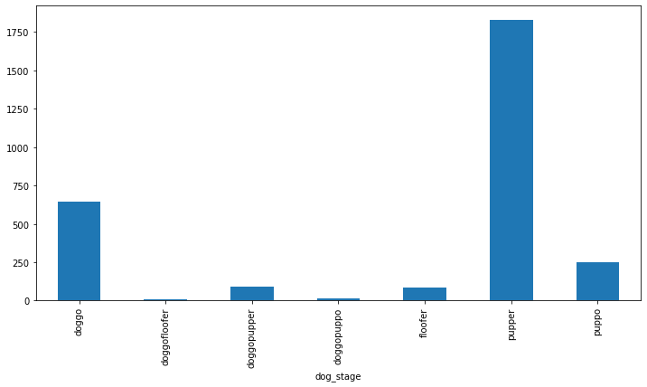

```python
# Dogs Stage according to total rate.
```

## The highst Dog stage according to rating score is Pupper

from the graph is showig that the relation between retweet count with favorite counts is almost directly propotional.

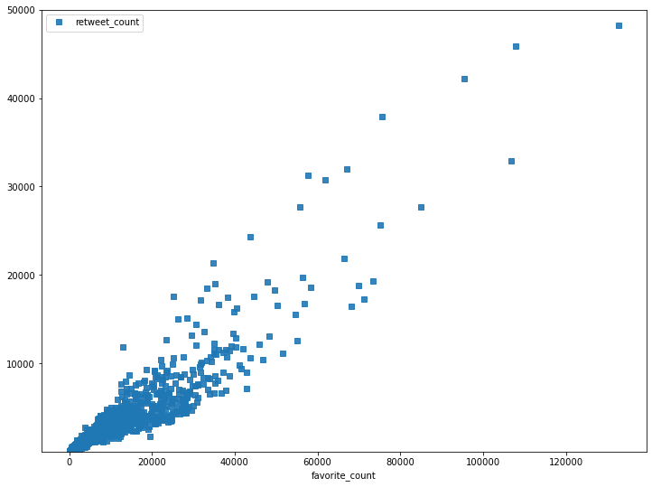

```python
# retweet count over time with favorite counts
```